# FML_Assignment_4

Christine Donovan

2026-10-24

## Library and Pharmaceuticals .CSV file

```r
library(tidyverse)
library(factoextra)
library(knitr)

pharma<-read.csv("Pharmaceuticals.csv")
```

## Read headers

```r
head(pharma)
```

```
##   Symbol                Name Market_Cap Beta PE_Ratio  ROE  ROA Asset_Turnover
## 1    ABT Abbott Laboratories      68.44 0.32     24.7 26.4 11.8            0.7
## 2    AGN      Allergan, Inc.       7.58 0.41     82.5 12.9  5.5            0.9
## 3    AHM        Amersham plc       6.30 0.46     20.7 14.9  7.8            0.9
## 4    AZN     AstraZeneca PLC      67.63 0.52     21.5 27.4 15.4            0.9
## 5    AVE             Aventis      47.16 0.32     20.1 21.8  7.5            0.6
## 6    BAY            Bayer AG      16.90 1.11     27.9  3.9  1.4            0.6
##   Leverage Rev_Growth Net_Profit_Margin Median_Recommendation Location Exchange
## 1     0.42       7.54              16.1          Moderate Buy       US     NYSE
## 2     0.60       9.16               5.5          Moderate Buy   CANADA     NYSE
## 3     0.27       7.05              11.2            Strong Buy       UK     NYSE
## 4     0.00      15.00              18.0         Moderate Sell       UK     NYSE
## 5     0.34      26.81              12.9          Moderate Buy   FRANCE     NYSE
## 6     0.00      -3.17               2.6                  Hold  GERMANY     NYSE
```

```r
pharma_num <- pharma[, 3:11]          # columns 3-11 = variables 1 to 9
rownames(pharma_num) <- pharma$Symbol # label rows with ticker symbols
summary(pharma_num)
```

```
##    Market_Cap          Beta           PE_Ratio          ROE
##  Min.   :  0.41   Min.   :0.1800   Min.   : 3.60   Min.   : 3.9
##  1st Qu.:  6.30   1st Qu.:0.3500   1st Qu.:18.90   1st Qu.:14.9
##  Median : 48.19   Median :0.4600   Median :21.50   Median :22.6
##  Mean   : 57.65   Mean   :0.5257   Mean   :25.46   Mean   :25.8
##  3rd Qu.: 73.84   3rd Qu.:0.6500   3rd Qu.:27.90   3rd Qu.:31.0
##  Max.   :199.47   Max.   :1.1100   Max.   :82.50   Max.   :62.9
##       ROA        Asset_Turnover    Leverage        Rev_Growth
##  Min.   : 1.40   Min.   :0.3    Min.   :0.0000   Min.   :-3.17
##  1st Qu.: 5.70   1st Qu.:0.6    1st Qu.:0.1600   1st Qu.: 6.38
##  Median :11.20   Median :0.6    Median :0.3400   Median : 9.37
##  Mean   :10.51   Mean   :0.7    Mean   :0.5857   Mean   :13.37
##  3rd Qu.:15.00   3rd Qu.:0.9    3rd Qu.:0.6000   3rd Qu.:21.87
##  Max.   :20.30   Max.   :1.1    Max.   :3.5100   Max.   :34.21
##  Net_Profit_Margin
##  Min.   : 2.6
##  1st Qu.:11.2
##  Median :16.1
##  Mean   :15.7
##  3rd Qu.:21.1
##  Max.   :25.5
```

## Normalize

```r
pharma_norm <- scale(pharma_num)
summary(pharma_norm)
```

```
##    Market_Cap           Beta            PE_Ratio            ROE
##  Min.   :-0.9768   Min.   :-1.3466   Min.   :-1.3404   Min.   :-1.4515
##  1st Qu.:-0.8763   1st Qu.:-0.6844   1st Qu.:-0.4023   1st Qu.:-0.7223
##  Median :-0.1614   Median :-0.2560   Median :-0.2429   Median :-0.2118
##  Mean   : 0.0000   Mean   : 0.0000   Mean   : 0.0000   Mean   : 0.0000
##  3rd Qu.: 0.2762   3rd Qu.: 0.4841   3rd Qu.: 0.1495   3rd Qu.: 0.3450
##  Max.   : 2.4200   Max.   : 2.2758   Max.   : 3.4971   Max.   : 2.4597
##       ROA          Asset_Turnover       Leverage          Rev_Growth
##  Min.   :-1.7128   Min.   :-1.8451   Min.   :-0.74966   Min.   :-1.4971
##  1st Qu.:-0.9047   1st Qu.:-0.4613   1st Qu.:-0.54487   1st Qu.:-0.6328
##  Median : 0.1289   Median :-0.4613   Median :-0.31449   Median :-0.3621
##  Mean   : 0.0000   Mean   : 0.0000   Mean   : 0.00000   Mean   : 0.0000
##  3rd Qu.: 0.8430   3rd Qu.: 0.9225   3rd Qu.: 0.01828   3rd Qu.: 0.7693
##  Max.   : 1.8389   Max.   : 1.8451   Max.   : 3.74280   Max.   : 1.8862
##  Net_Profit_Margin
##  Min.   :-1.99560
##  1st Qu.:-0.68504
##  Median : 0.06168
##  Mean   : 0.00000
##  3rd Qu.: 0.82364
##  Max.   : 1.49416
```

**Normalization and weights:** Market_Cap’s range is about 200 times larger than Beta’s. This is a problem for k-means because it groups firms by Euclidean distance, so variables measured in large numbers would dominate the distance and the clustering. To prevent this, I normalized all nine variables using z-scores, which gives every variable equal weight, so that no variable dominates just because of its units. Since the analyst wants to understand the industry using all nine financial measures, each should contribute equally.

## Choose k

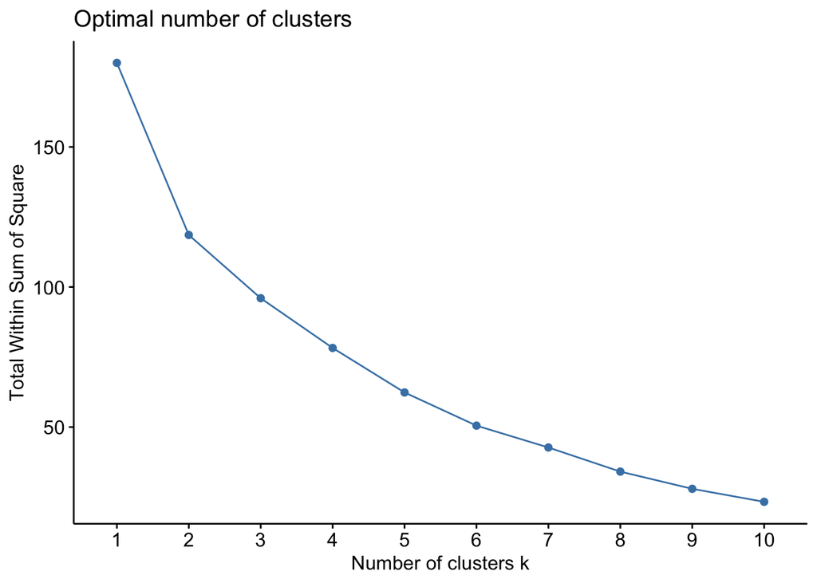

```r
set.seed(123)
fviz_nbclust(pharma_norm, kmeans, method = "wss", nstart = 25)
```

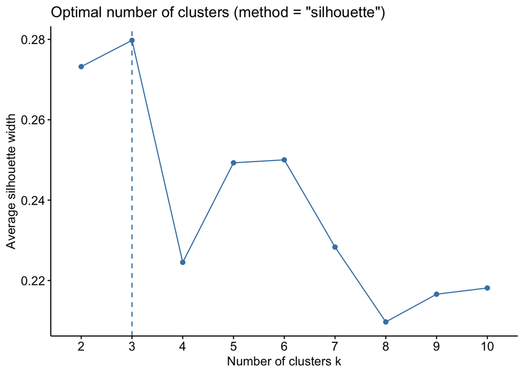

```r
fviz_nbclust(pharma_norm, kmeans, method = "silhouette", nstart = 25)
```

**Choosing k:** In the elbow chart, the steep drop ends at k = 2 (180 → about 119), after which the line declines gradually, with no sharp corner. The silhouette is clearly highest at k = 3 (about 0.28), which R marks with the dashed line; k = 2 is close behind at about 0.27, while k = 4 drops sharply to about 0.22. I chose k = 3 because the silhouette method directly measures how well firms fit their clusters, while the elbow is soft, making it the weaker of the two signals. Setting k = 2 would also be too limiting for the analyst’s goal, since two clusters would likely only separate large firms from small ones.

## Running k-means (k = 3)

```r
set.seed(123)
k3 <- kmeans(pharma_norm, centers = 3, nstart = 25)
k3$size
```

```
## [1]  4 11  6
```

```r
k3$cluster
```

```
##  ABT  AGN  AHM  AZN  AVE  BAY  BMY CHTT  ELN  LLY  GSK  IVX  JNJ  MRX  MRK  NVS
##    2    1    1    2    3    1    2    3    3    2    2    3    2    3    2    2
##  PFE  PHA  SGP  WPI  WYE
##    2    1    2    3    2
```

```r
k3$centers
```

```
##   Market_Cap       Beta   PE_Ratio        ROE        ROA Asset_Turnover
## 1 -0.6125361  0.2698666  1.3143935 -0.9609057 -1.0174553      0.2306328
## 2  0.6733825 -0.3586419 -0.2763512  0.6565978  0.8344159      0.4612656
## 3 -0.8261772  0.4775991 -0.3696184 -0.5631589 -0.8514589     -0.9994088
##     Leverage Rev_Growth Net_Profit_Margin
## 1 -0.3592866 -0.5757385        -1.3784169
## 2 -0.3331068 -0.2902163         0.6823310
## 3  0.8502201  0.9158889        -0.3319956
```

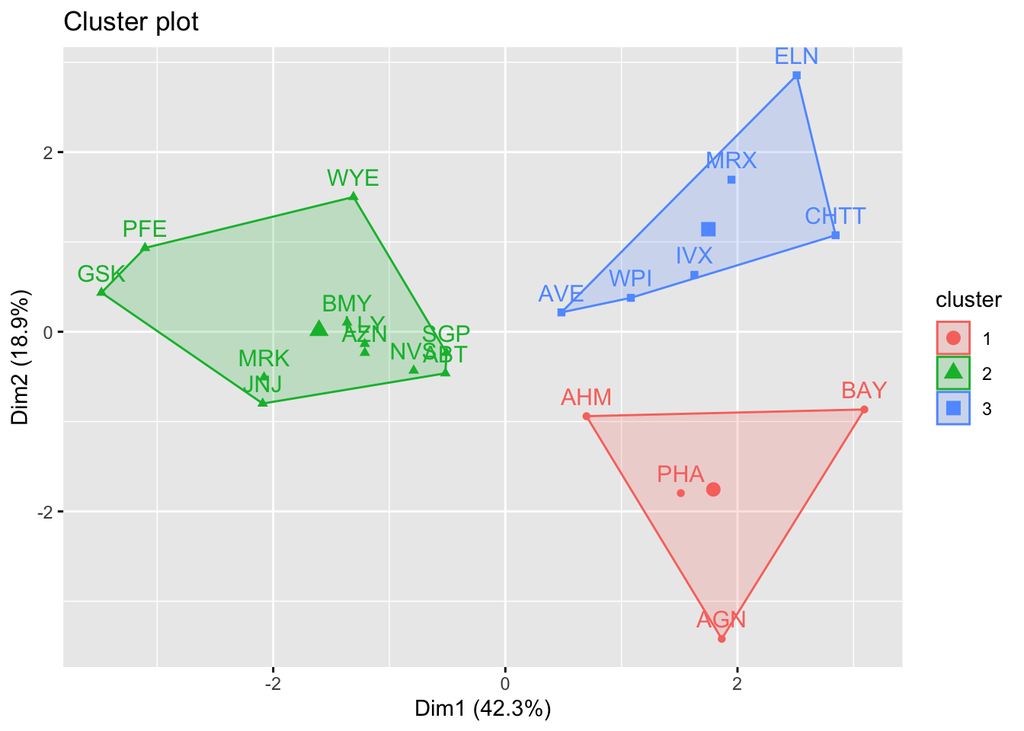

```r
fviz_cluster(k3, data = pharma_norm)
```

## Robustness check: removing outliers

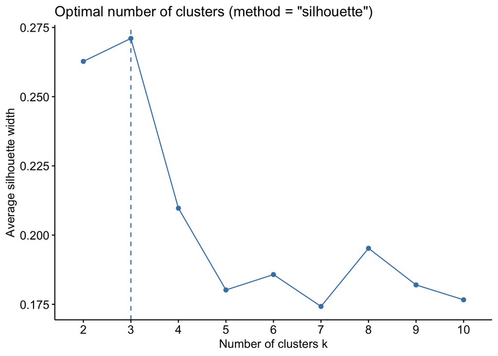

```r
# Remove the two extreme outliers (z-scores above 3)
pharma_trim <- pharma_num[!rownames(pharma_num) %in% c("AGN", "CHTT"), ]
trim_norm   <- scale(pharma_trim)

# Does k = 3 still have the highest silhouette?
set.seed(123)
fviz_nbclust(trim_norm, kmeans, method = "silhouette", nstart = 25)
```

```r
# Re-run k-means and compare with the original clusters
set.seed(123)
k3_trim <- kmeans(trim_norm, centers = 3, nstart = 25)

table(Original = k3$cluster[rownames(pharma_trim)],
      Without_Outliers = k3_trim$cluster)
```

```
##         Without_Outliers
## Original  1  2  3
##        1  0  0  3
##        2 11  0  0
##        3  0  5  0
```

**Robustness check:** To check for robustness, I removed the two extreme outliers that were more than 3 standard deviations from the average: Allergan (P/E z-score of 3.50) from Cluster 1, and Chattem (Leverage z-score of 3.74) from Cluster 3. I then re-normalized the remaining 19 firms and reran the analysis. The results: k = 3 still had the highest silhouette, and every remaining firm stayed in the same cluster, including all 11 firms in Cluster 2. Therefore, the clusters are robust; they reflect real patterns, not just the influence of the two outliers.

## Interpreting the clusters (part b)

```r
industry_avg <- colMeans(pharma_num)
cluster_avg  <- aggregate(pharma_num, by = list(Cluster = k3$cluster), FUN = mean)

profile_table <- function(k) {
  z <- k3$centers[k, ]
  data.frame(
    Variable       = names(z),
    `z-score`      = round(z, 2),
    `Cluster Avg`  = round(unlist(cluster_avg[k, -1]), 2),
    `Industry Avg` = round(industry_avg, 2),
    `Stands Out`   = ifelse(z >= 0.5, "Above average",
                     ifelse(z <= -0.5, "Below average", "About average")),
    check.names = FALSE,
    row.names   = NULL
  )
}
```

## Cluster 1

```r
kable(profile_table(1), caption = "Cluster 1 Profile")
```

Cluster 1 Profile

| Variable | z-score | Cluster Avg | Industry Avg | Stands Out |
| --- | --- | --- | --- | --- |
| Market_Cap | -0.61 | 21.75 | 57.65 | Below average |
| Beta | 0.27 | 0.60 | 0.53 | About average |
| PE_Ratio | 1.31 | 46.90 | 25.46 | Above average |
| ROE | -0.96 | 11.30 | 25.80 | Below average |
| ROA | -1.02 | 5.10 | 10.51 | Below average |
| Asset_Turnover | 0.23 | 0.75 | 0.70 | About average |
| Leverage | -0.36 | 0.30 | 0.59 | About average |
| Rev_Growth | -0.58 | 7.01 | 13.37 | Below average |
| Net_Profit_Margin | -1.38 | 6.65 | 15.70 | Below average |

**Cluster 1:** In Cluster 1, Net_Profit_Margin (−1.38 z-score) is significantly below average, along with four other variables (ROA, ROE, Market_Cap, and Rev_Growth) that are below industry standards. What stands out in this cluster is PE_Ratio (+1.31 z-score), which is significantly higher, reflecting a P/E of 46.9, almost double the industry average of 25.5. The rest of the variables were close to industry standards. The high P/E indicates that earnings for this group (Allergan, Amersham, Bayer, and Pharmacia) are particularly low compared to industry standards, yet investors are still willing to pay a premium for these stocks, perhaps anticipating a recovery.

## Cluster 2

```r
kable(profile_table(2), caption = "Cluster 2 Profile")
```

Cluster 2 Profile

| Variable | z-score | Cluster Avg | Industry Avg | Stands Out |
| --- | --- | --- | --- | --- |
| Market_Cap | 0.67 | 97.11 | 57.65 | Above average |
| Beta | -0.36 | 0.43 | 0.53 | About average |
| PE_Ratio | -0.28 | 20.95 | 25.46 | About average |
| ROE | 0.66 | 35.70 | 25.80 | Above average |
| ROA | 0.83 | 14.95 | 10.51 | Above average |
| Asset_Turnover | 0.46 | 0.80 | 0.70 | About average |
| Leverage | -0.33 | 0.33 | 0.59 | About average |
| Rev_Growth | -0.29 | 10.16 | 13.37 | About average |
| Net_Profit_Margin | 0.68 | 20.17 | 15.70 | Above average |

**Cluster 2:** Looking at the table above, what stands out is that Market_Cap is significantly higher, at $97.1B vs. $57.7B for the industry. All three profitability measures (ROE, ROA, and Net_Profit_Margin) are also above the industry average, and none of the variables are below average. The ±0.5 rule labels Beta (−0.36) and Leverage (−0.33) “About average,” but both lean lower, meaning these firms are slightly less volatile and carry less debt. Overall, Cluster 2 contains the industry’s large, highly profitable, and relatively stable established firms, such as Pfizer, Johnson & Johnson, and Merck.

## Cluster 3

```r
kable(profile_table(3), caption = "Cluster 3 Profile")
```

Cluster 3 Profile

| Variable | z-score | Cluster Avg | Industry Avg | Stands Out |
| --- | --- | --- | --- | --- |
| Market_Cap | -0.83 | 9.23 | 57.65 | Below average |
| Beta | 0.48 | 0.65 | 0.53 | About average |
| PE_Ratio | -0.37 | 19.43 | 25.46 | About average |
| ROE | -0.56 | 17.30 | 25.80 | Below average |
| ROA | -0.85 | 5.98 | 10.51 | Below average |
| Asset_Turnover | -1.00 | 0.48 | 0.70 | Below average |
| Leverage | 0.85 | 1.25 | 0.59 | Above average |
| Rev_Growth | 0.92 | 23.49 | 13.37 | Above average |
| Net_Profit_Margin | -0.33 | 13.52 | 15.70 | About average |

**Cluster 3:** This is one of the most interesting groups, with the highest Rev_Growth at 23.5%, almost double the industry average, and Leverage at 1.25, just over double the industry average. This means these firms are borrowing heavily to support their growth, such as through research or acquisitions. On the flip side, this cluster reflects a group of smaller, somewhat more volatile companies (Aventis, Chattem, Elan, IVAX, Medicis, and Watson), with Asset_Turnover, ROA, Market_Cap, and ROE all well below industry standards. What this reflects is heavy debt-financed investment that has yet to pay off, making this group riskier, but with higher potential rewards.

## Part (c): Patterns in Variables 10–12

```r
pharma$Cluster <- k3$cluster
cl <- paste("Cluster", pharma$Cluster)

kable(as.data.frame.matrix(table(cl, pharma$Median_Recommendation)),
      caption = "Median Recommendation by Cluster")
```

Median Recommendation by Cluster

|  | Hold | Moderate Buy | Moderate Sell | Strong Buy |
| --- | --- | --- | --- | --- |
| Cluster 1 | 2 | 1 | 0 | 1 |
| Cluster 2 | 6 | 3 | 2 | 0 |
| Cluster 3 | 1 | 3 | 2 | 0 |

```r
kable(as.data.frame.matrix(table(cl, pharma$Location)),
      caption = "Location by Cluster")
```

Location by Cluster

|  | CANADA | FRANCE | GERMANY | IRELAND | SWITZERLAND | UK | US |
| --- | --- | --- | --- | --- | --- | --- | --- |
| Cluster 1 | 1 | 0 | 1 | 0 | 0 | 1 | 1 |
| Cluster 2 | 0 | 0 | 0 | 0 | 1 | 2 | 8 |
| Cluster 3 | 0 | 1 | 0 | 1 | 0 | 0 | 4 |

```r
kable(as.data.frame.matrix(table(cl, pharma$Exchange)),
      caption = "Exchange by Cluster")
```

Exchange by Cluster

|  | AMEX | NASDAQ | NYSE |
| --- | --- | --- | --- |
| Cluster 1 | 0 | 0 | 4 |
| Cluster 2 | 0 | 0 | 11 |
| Cluster 3 | 1 | 1 | 4 |

**Patterns in variables 10–12:** Cluster 2’s most common recommendation is Hold (6 of 11 firms), consistent with large, well-established companies that analysts view as stable, with slower growth and limited upside. Cluster 1 contains the only Strong Buy, which is consistent with established companies whose earnings are depressed and are anticipated to recover. Cluster 3’s recommendations are split between Moderate Buy (3) and Moderate Sell (2), reflecting analyst disagreement about these riskier, high-growth firms. For location, Clusters 2 and 3 are mostly US companies, whereas Cluster 1 is mostly non-US companies. Most companies trade on the NYSE, except for two small companies in Cluster 3, IVAX ($2.6B) and Chattem ($0.41B, the smallest in the dataset), which trade on AMEX and NASDAQ; smaller companies often list on these smaller exchanges. Since there are only 21 firms, with some clusters containing just 4 to 6 companies, these patterns are suggestive rather than conclusive.

## Part (d): Cluster names

**Cluster 1: Rebound Candidates:** These companies have depressed earnings, shown by a high P/E alongside weak profits and growth. Most are non-US firms, and the cluster includes the only Strong Buy rating, suggesting investors expect a recovery; however, stocks like these may also be value traps.

**Cluster 2: Blue Chip Steadies:** These are large, highly profitable, stable firms with mostly Hold ratings.

**Cluster 3: Speculative Rockets:** These companies are smaller, fast-growing, heavily leveraged, and riskier, with split analyst recommendations.